# PREPROCESADO

1. IMPORTACIÓN DE LOS DATOS
2. DESCRIPCIÓN GENERAL DEL DATASET : INSPECCIÓN ANALÍTICA Y VISUAL
3. TRANSFORMACIÓN Y CREACIÓN DE VARIABLES
4. ESTUDIO Y TRATAMIENTO DE OUTLIERS
5. ESTUDIO Y TRATAMIENTO DE VALORES PERDIDOS

```r
#Importación de librerías

if (!"kableExtra" %in% installed.packages()) install.packages("kableExtra")
if (!"purrr" %in% installed.packages()) install.packages("purrr")
if (!"questionr" %in% installed.packages()) install.packages("questionr")
if (!"psych" %in% installed.packages()) install.packages("psych")
if (!"car" %in% installed.packages()) install.packages("car")
if (!"corrplot" %in% installed.packages()) install.packages("corrplot")
if (!"dplyr" %in% installed.packages()) install.packages("dplyr")
if (!"tidyverse" %in% installed.packages()) install.packages("tidyverse")
if (!"ggplot2" %in% installed.packages()) install.packages("ggplot2")
if (!"lubridate" %in% installed.packages()) install.packages("lubridate")
if (!"mice" %in% installed.packages()) install.packages("mice")
if (!"readr" %in% installed.packages()) install.packages("readr")
```

```r
# Se importan todas las librerías que pueden resultar de utilidad aunque no necesariamente se utilicen todas

library(kableExtra)
# librería para facilitar la creación de tablas complejas y su manipulación
library(purrr)
# herramientas para la programación funcional y mejora el trabajo con funciones y la vectorización. Mejora el acceso a elementos dentro de un loop y el acceso a listas
library(questionr)
# conjunto de funciones que facilitan el procesamiento y análisis del estudio: tablas de contingencia, complementos para recodificación de datos,
library(psych)
# librería para el análisis multivariado y construcción de escalas utilizando el análisis factorial y de componentes así como estadísticas descriptivas básicas
library(car)
# librería para aplicar regresiones
library(corrplot)
# aplicada para crear gráficos de correlación
library(dplyr)
# librería con una serie de funciones que simplifican las acciones sobre los datos, muy útiles y bastante rápidas para la manipulación de data frames
library(tidyverse)
# colección de paquetes disponibles en R y orientados a la manipulación, importación, exploración y visualización de datos
library(ggplot2)
# librería de amplio uso en la visualización de datos
library(lubridate)
# permite separar los componentes de la fecha y hora cuando no tienen una estrucutra definida
library(mice)
# librería para imputar datos multivariantes incompletos mediante ecuaciones encadenadas y así checkear datos perdidos
library(readr)
# librería para facilitar la importación de datos desde diversas fuentes hacia un objeto estructurado, posee funciones para importar todo tipo de archivos
```

### 1. IMPORTACIÓN DE LOS DATOS

Tenemos dos alternativas para la lectura de los datos: fijando un directorio de trabajo o leyendo los dataset desde una ubicación web. Se opta por importar los datos desde github, enlace: https://raw.githubusercontent.com/TFM123456/Big_Data_and_Data_Science_UCM/main/Galicia_definitivo.csv.

Por favor, fije su directorio de trabajo en la carpeta del GRUPO 3.

```r
#setwd("Rellenar con el directorio de trabajo porfavor")
```

```r
#datos <- read.csv("DATASET TFM_v2_12072021.csv")
#datos_galicia <- read.csv("Galicia_definitivo.csv")
```

```r
#Lectura de datos desde github
library (readr) # librería para leer datos
url = "https://raw.githubusercontent.com/TFM123456/Big_Data_and_Data_Science_UCM/main/Galicia_definitivo.csv"  # URL actualizada 12/08/2021- debería funcionar para todos

datos_galicia = as.data.frame(read.csv(url(url)))
```

```r
#url1 = "https://raw.githubusercontent.com/TFM123456/Datos/main/DATASET%20TFM_v2_12072021.csv"  # URL actualizada 12/08/2021- debería funcionar para todos
#datos = as.data.frame(read.csv(url(url1)))
```

### 2. DESCRIPCIÓN GENERAL DEL DATASET : INSPECCIÓN ANALÍTICA Y VISUAL

En este script contamos con 2 datasets. El de “datos” reúne la información del conjunto del territorio español y el de “datos_galicia” en el que se va a fundamentar este proyecto. Este dataset es una combinación de dos anteriores, la parte relativa a Galicia del de datos y un conjunto de variables geográficas y geológicas añadidas a posteriori.

```r
str(datos_galicia)
```

```
## 'data.frame':    20545 obs. of  33 variables:
##  $ ï..Concat      : chr  "36942 15" "36946 15" "36947 15" "36947 15" ...
##  $ id             : int  2001150021 2001150088 2001150094 2001150111 2001150145 2001150151 2001150153 2001150165 2001150181 2001150183 ...
##  $ superficie     : num  5 1.5 1.5 3.8 1.5 1.1 1.5 1.3 1.5 3 ...
##  $ fecha          : chr  "20/02/2001" "24/02/2001" "25/02/2001" "25/02/2001" ...
##  $ lat            : num  43.7 42.9 43.2 42.9 43.7 ...
##  $ lng            : num  -8.04 -9.11 -8.69 -9.08 -7.98 ...
##  $ latlng_explicit: int  1 1 1 1 1 1 1 1 1 1 ...
##  $ idcomunidad    : int  3 3 3 3 3 3 3 3 3 3 ...
##  $ idprovincia    : int  15 15 15 15 15 15 15 15 15 15 ...
##  $ idmunicipio    : int  22 34 19 45 22 42 52 62 19 23 ...
##  $ municipio      : chr  "CEDEIRA" "DUMBRÃƒÂ\215A" "CARBALLO" "MAZARICOS" ...
##  $ causa          : int  2 4 4 4 2 5 4 4 4 4 ...
##  $ causa_supuesta : int  1 1 1 1 1 NA 1 1 1 1 ...
##  $ causa_desc     : int  30 0 0 1 30 0 3 0 0 0 ...
```

[output cut: 19 more lines]

```r
length(names(datos_galicia))
```

```
## [1] 33
```

Tenemos un total de 33 variables, de las cuales 14 están en el formato de character, 16 en formato de entero y 3 en formato numérico. En un primer vistazo vemos que el tipo de formato de estas variables lo tendríamos que transformar, para poder trabajar mejor con ellas. En este sentido vamos a transformar la variable de fecha en el formato date y las variables geográficas y geológicas en numéricas:

```r
datos_galicia[,c(4)] = as.Date(datos_galicia$fecha, format ="%d/%m/%Y")
```

```r
datos_galicia[,c(23:33)] <- lapply(datos_galicia[,c(23:33)], as.numeric)
```

También hemos considerado eliminar las variables de id concatenado, latlng_explicit y causa_supuesta, porque por la descripción de su contenido la relevancia en nuestro análisis va a ser muy reducida.

```r
datos_galicia[,c("ï..Concat")] = NULL
datos_galicia[,c("latlng_explicit")] = NULL
datos_galicia[,c("causa_supuesta")] = NULL
datos_galicia[,c("causa_desc")] = NULL # Eliminamos la variable de la descripción de las causas para no duplicar contenido
datos_galicia[,c("idcomunidad")] = NULL
```

```r
length(names(datos_galicia))
```

```
## [1] 28
```

```r
# Después de realizar las primeras transformaciones a los tipos de datos sin alterar su contenido, hacemos un análisis rápido del dataset y comprobamos la no duplicidad de ids.

length(unique(datos_galicia$id))
```

```
## [1] 20545
```

```r
# No tenemos valores duplicados porque el número total de valores únicos es el mismo que el número de filas
```

```r
summary(datos_galicia)
```

```
##        id              superficie          fecha                 lat
##  Min.   :2.001e+09   Min.   :   1.00   Min.   :2001-02-14   Min.   :27.62
##  1st Qu.:2.003e+09   1st Qu.:   1.50   1st Qu.:2003-03-23   1st Qu.:42.20
##  Median :2.005e+09   Median :   2.50   Median :2005-04-09   Median :42.46
##  Mean   :2.006e+09   Mean   :  15.48   Mean   :2006-05-24   Mean   :42.55
##  3rd Qu.:2.009e+09   3rd Qu.:   6.00   3rd Qu.:2009-08-14   3rd Qu.:42.91
##  Max.   :2.015e+09   Max.   :7316.77   Max.   :2015-12-30   Max.   :78.64
##                                                             NA's   :2
##       lng          idprovincia     idmunicipio      municipio
##  Min.   :-9.294   Min.   :15.00   Min.   :  1.00   Length:20545
##  1st Qu.:-8.418   1st Qu.:15.00   1st Qu.: 21.00   Class :character
##  Median :-7.978   Median :32.00   Median : 43.00   Mode  :character
##  Mean   :-7.981   Mean   :27.56   Mean   : 47.82
##  3rd Qu.:-7.540   3rd Qu.:32.00   3rd Qu.: 65.00
##  Max.   :46.524   Max.   :36.00   Max.   :999.00
##  NA's   :2
##      causa          muertos         heridos        time_ctrl
##  Min.   :1.000   Min.   :1.000   Min.   :1.00    Min.   :    0.0
##  1st Qu.:4.000   1st Qu.:1.000   1st Qu.:1.00    1st Qu.:   90.0
##  Median :4.000   Median :1.000   Median :1.00    Median :  135.0
##  Mean   :4.005   Mean   :1.143   Mean   :1.45    Mean   :  230.1
##  3rd Qu.:4.000   3rd Qu.:1.000   3rd Qu.:2.00    3rd Qu.:  230.0
##  Max.   :6.000   Max.   :2.000   Max.   :6.00    Max.   :10125.0
##                  NA's   :20538   NA's   :20505
##     time_ext          personal          medios            gastos
##  Min.   :   15.0   Min.   :  0.00   Min.   :  0.000   Min.   :     0
##  1st Qu.:  143.0   1st Qu.:  7.00   1st Qu.:  1.000   1st Qu.:  1090
##  Median :  225.0   Median : 13.00   Median :  2.000   Median :  2308
##  Mean   :  384.6   Mean   : 18.95   Mean   :  3.283   Mean   :  8353
##  3rd Qu.:  380.0   3rd Qu.: 22.00   3rd Qu.:  4.000   3rd Qu.:  6845
##  Max.   :12637.0   Max.   :855.00   Max.   :205.000   Max.   :564585
##                                                       NA's   :16951
##     perdidas           ALTITUD          TMEDIA      PRECIPITACION
##  Min.   :       0   Min.   : 58.0   Min.   :-2.40   Min.   : 0.0000
##  1st Qu.:       0   1st Qu.: 58.0   1st Qu.:12.70   1st Qu.: 0.0000
##  Median :    1701   Median :143.0   Median :18.00   Median : 0.0000
##  Mean   :   33194   Mean   :152.7   Mean   :17.02   Mean   : 0.6513
##  3rd Qu.:    6492   3rd Qu.:143.0   3rd Qu.:21.50   3rd Qu.: 0.0000
##  Max.   :15426315   Max.   :445.0   Max.   :31.20   Max.   :79.7000
##  NA's   :6784       NA's   :242     NA's   :242     NA's   :242
##       TMIN             TMAX            DIR           VELMEDIA
##  Min.   :-10.00   Min.   : 0.00   Min.   : 0.00   Min.   : 0.000
##  1st Qu.:  5.50   1st Qu.:19.00   1st Qu.: 5.00   1st Qu.: 1.400
##  Median : 11.20   Median :24.00   Median :20.00   Median : 1.900
##  Mean   : 10.03   Mean   :24.01   Mean   :18.56   Mean   : 2.319
##  3rd Qu.: 15.20   3rd Qu.:28.90   3rd Qu.:30.00   3rd Qu.: 2.800
##  Max.   : 23.40   Max.   :42.00   Max.   :99.00   Max.   :10.800
##  NA's   :242      NA's   :242     NA's   :242     NA's   :242
##      RACHA             SOL            PRESMAX        PRESMIN
##  Min.   : 0.000   Min.   : 0.000   Min.   :   0   Min.   :   0.0
##  1st Qu.: 6.100   1st Qu.: 6.400   1st Qu.:1000   1st Qu.: 995.4
##  Median : 8.100   Median : 9.400   Median :1005   Median :1001.3
##  Mean   : 8.411   Mean   : 8.547   Mean   :1001   Mean   : 996.8
##  3rd Qu.:10.800   3rd Qu.:11.400   3rd Qu.:1011   3rd Qu.:1007.1
##  Max.   :31.900   Max.   :14.800   Max.   :1031   Max.   :1027.8
##  NA's   :242      NA's   :242      NA's   :242    NA's   :242
```

```r
#Aproximadamente la mitad de las variables tienen valores perdidos, que analizaremos luego.
```

```r
dim(datos_galicia)
```

```
## [1] 20545    28
```

Revisamos de nuevo las numéricas para ver si alguna más podría ser transformada en factor,y realizaremos esta transformación en el apartado siguiente. En la transformación de variables que se realizarán a continuación , cambiará el contenido de la variable y el tipo de datos. En algunos casos la intención es mejorar la interpretabilidad del modelo y en otros, evitar la pérdida de observaciones en el tratamiento de valores extremos y de valores perdidos.

```r
head(Filter(is.numeric, datos_galicia))
```

|  | id | superficie | lat | lng | idprovincia | idmunicipio | causa | muertos | heridos | time_ctrl | time_ext | personal | medios | gastos | perdidas | ALTITUD | TMEDIA | PRECIPITACION | TMIN | TMAX | DIR | VELMEDIA | RACHA | SOL | PRESMAX | PRESMIN |
| --- | --- | --- | --- | --- | --- | --- | --- | --- | --- | --- | --- | --- | --- | --- | --- | --- | --- | --- | --- | --- | --- | --- | --- | --- | --- | --- |
| 1 | 2001150021 | 5.0 | 43.70358 | -8.038777 | 15 | 22 | 2 | NA | NA | 235 | 270 | 14 | 2 | NA | 7013 | 58 | 11.3 | 0 | 7.0 | 15.6 | 11 | 3.6 | 16.9 | 10.2 | 1025.4 | 1021.0 |
| 2 | 2001150088 | 1.5 | 42.93692 | -9.114350 | 15 | 34 | 4 | NA | NA | 470 | 530 | 14 | 1 | NA | 1497 | 58 | 11.7 | 0 | 9.4 | 14.0 | 34 | 4.2 | 11.4 | 9.4 | 1006.6 | 1003.9 |
| 3 | 2001150094 | 1.5 | 43.18684 | -8.685470 | 15 | 19 | 4 | NA | NA | 125 | 135 | 5 | 0 | NA | 1028 | 58 | 9.0 | 0 | 6.5 | 11.6 | 4 | 5.0 | 11.1 | 10.2 | 1011.3 | 1006.6 |
| 4 | 2001150111 | 3.8 | 42.91748 | -9.082862 | 15 | 45 | 4 | NA | NA | 1050 | 1051 | 14 | 1 | NA | 3119 | 58 | 9.0 | 0 | 6.5 | 11.6 | 4 | 5.0 | 11.1 | 10.2 | 1011.3 | 1006.6 |
| 5 | 2001150145 | 1.5 | 43.69989 | -7.984566 | 15 | 22 | 2 | NA | NA | 110 | 155 | 9 | 1 | NA | 126 | 58 | 13.9 | 0 | 10.4 | 17.4 | 5 | 5.3 | 13.9 | 12.1 | 1018.6 | 1015.4 |
| 6 | 2001150151 | 1.1 | 42.75865 | -8.917814 | 15 | 42 | 5 | NA | NA | 190 | 210 | 18 | 2 | NA | 234 | 58 | 13.9 | 0 | 10.4 | 17.4 | 5 | 5.3 | 13.9 | 12.1 | 1018.6 | 1015.4 |

```r
#Se va a crear un subset de variables numéricas y otro de categóricas para identificar mejor la naturaleza de las variables.

input<-as.data.frame(datos_galicia[,-(1)])
row.names(input)<-datos_galicia$id

numericas_input <- input %>% select(is.numeric)
no_numericas_input <- input %>% select(!is.numeric)

length(names(numericas_input))
```

```
## [1] 25
```

```r
length(names(no_numericas_input))
```

```
## [1] 2
```

```r
# Reproducir el código auxiliar de warning para prevenir errores en la representación de gráficos

warning = FALSE
```

### 3. TRANSFORMACIÓN Y CREACIÓN DE NUEVAS VARIABLES

Vamos a hacer una revisión rápida del contenido de cada una de las variables :

```r
head(datos_galicia)
```

|  | id | superficie | fecha | lat | lng | idprovincia | idmunicipio | municipio | causa | muertos | heridos | time_ctrl | time_ext | personal | medios | gastos | perdidas | ALTITUD | TMEDIA | PRECIPITACION | TMIN | TMAX | DIR | VELMEDIA | RACHA | SOL | PRESMAX | PRESMIN |
| --- | --- | --- | --- | --- | --- | --- | --- | --- | --- | --- | --- | --- | --- | --- | --- | --- | --- | --- | --- | --- | --- | --- | --- | --- | --- | --- | --- | --- |
| 1 | 2001150021 | 5.0 | 2001-02-20 | 43.70358 | -8.038777 | 15 | 22 | CEDEIRA | 2 | NA | NA | 235 | 270 | 14 | 2 | NA | 7013 | 58 | 11.3 | 0 | 7.0 | 15.6 | 11 | 3.6 | 16.9 | 10.2 | 1025.4 | 1021.0 |
| 2 | 2001150088 | 1.5 | 2001-02-24 | 42.93692 | -9.114350 | 15 | 34 | DUMBRÃƒÂ\215A | 4 | NA | NA | 470 | 530 | 14 | 1 | NA | 1497 | 58 | 11.7 | 0 | 9.4 | 14.0 | 34 | 4.2 | 11.4 | 9.4 | 1006.6 | 1003.9 |
| 3 | 2001150094 | 1.5 | 2001-02-25 | 43.18684 | -8.685470 | 15 | 19 | CARBALLO | 4 | NA | NA | 125 | 135 | 5 | 0 | NA | 1028 | 58 | 9.0 | 0 | 6.5 | 11.6 | 4 | 5.0 | 11.1 | 10.2 | 1011.3 | 1006.6 |
| 4 | 2001150111 | 3.8 | 2001-02-25 | 42.91748 | -9.082862 | 15 | 45 | MAZARICOS | 4 | NA | NA | 1050 | 1051 | 14 | 1 | NA | 3119 | 58 | 9.0 | 0 | 6.5 | 11.6 | 4 | 5.0 | 11.1 | 10.2 | 1011.3 | 1006.6 |
| 5 | 2001150145 | 1.5 | 2001-04-13 | 43.69989 | -7.984566 | 15 | 22 | CEDEIRA | 2 | NA | NA | 110 | 155 | 9 | 1 | NA | 126 | 58 | 13.9 | 0 | 10.4 | 17.4 | 5 | 5.3 | 13.9 | 12.1 | 1018.6 | 1015.4 |
| 6 | 2001150151 | 1.1 | 2001-04-13 | 42.75865 | -8.917814 | 15 | 42 | LOUSAME | 5 | NA | NA | 190 | 210 | 18 | 2 | NA | 234 | 58 | 13.9 | 0 | 10.4 | 17.4 | 5 | 5.3 | 13.9 | 12.1 | 1018.6 | 1015.4 |

```r
str(datos_galicia)
```

```
## 'data.frame':    20545 obs. of  28 variables:
##  $ id           : int  2001150021 2001150088 2001150094 2001150111 2001150145 2001150151 2001150153 2001150165 2001150181 2001150183 ...
##  $ superficie   : num  5 1.5 1.5 3.8 1.5 1.1 1.5 1.3 1.5 3 ...
##  $ fecha        : Date, format: "2001-02-20" "2001-02-24" ...
##  $ lat          : num  43.7 42.9 43.2 42.9 43.7 ...
##  $ lng          : num  -8.04 -9.11 -8.69 -9.08 -7.98 ...
##  $ idprovincia  : int  15 15 15 15 15 15 15 15 15 15 ...
##  $ idmunicipio  : int  22 34 19 45 22 42 52 62 19 23 ...
##  $ municipio    : chr  "CEDEIRA" "DUMBRÃƒÂ\215A" "CARBALLO" "MAZARICOS" ...
##  $ causa        : int  2 4 4 4 2 5 4 4 4 4 ...
##  $ muertos      : int  NA NA NA NA NA NA NA NA NA NA ...
##  $ heridos      : int  NA NA NA NA NA NA NA NA NA NA ...
##  $ time_ctrl    : int  235 470 125 1050 110 190 95 175 145 270 ...
##  $ time_ext     : int  270 530 135 1051 155 210 125 190 210 345 ...
##  $ personal     : int  14 14 5 14 9 18 14 19 6 9 ...
##  $ medios       : int  2 1 0 1 1 2 1 2 2 2 ...
##  $ gastos       : int  NA NA NA NA NA NA NA NA NA NA ...
##  $ perdidas     : int  7013 1497 1028 3119 126 234 2915 534 2254 1189 ...
##  $ ALTITUD      : num  58 58 58 58 58 58 58 58 58 58 ...
##  $ TMEDIA       : num  11.3 11.7 9 9 13.9 13.9 13.9 14.2 12.7 12.7 ...
##  $ PRECIPITACION: num  0 0 0 0 0 0 0 0 0 0 ...
##  $ TMIN         : num  7 9.4 6.5 6.5 10.4 10.4 10.4 10.4 8.8 8.8 ...
##  $ TMAX         : num  15.6 14 11.6 11.6 17.4 17.4 17.4 18 16.6 16.6 ...
##  $ DIR          : num  11 34 4 4 5 5 5 8 14 14 ...
##  $ VELMEDIA     : num  3.6 4.2 5 5 5.3 5.3 5.3 5.6 1.4 1.4 ...
##  $ RACHA        : num  16.9 11.4 11.1 11.1 13.9 13.9 13.9 12.8 9.2 9.2 ...
##  $ SOL          : num  10.2 9.4 10.2 10.2 12.1 12.1 12.1 11.8 11.8 11.8 ...
##  $ PRESMAX      : num  1025 1007 1011 1011 1019 ...
##  $ PRESMIN      : num  1021 1004 1007 1007 1015 ...
```

Por lo observado (ver código), podría ser significativo realizar las siguientes tranformaciones:

**- Transformación de idprovincia, municipio y comunidad**

Esta variable se va a categorizar porque así va a ser más informativa de esta forma y por su contenido no tiene sentido tratarla como si fuera numérica. De igual manera se procederá con la variable del municipio.

```r
datos_galicia$idprovincia[datos_galicia$idprovincia == 15] <- "A Coruña"
datos_galicia$idprovincia[datos_galicia$idprovincia == 27] <- "Lugo"
datos_galicia$idprovincia[datos_galicia$idprovincia == 32] <- "Ourense"
datos_galicia$idprovincia[datos_galicia$idprovincia == 36] <- "Pontevedra"

datos_galicia$idmunicipio <- datos_galicia$municipio # Eliminación de municipio

# Eliminación de la columna en formato numérico para no duplicar la información.
datos_galicia$municipio = NULL
```

```r
table(datos_galicia$idprovincia)
```

```
##
##   A Coruña       Lugo    Ourense Pontevedra
##       5313       2763       9237       3232
```

**- Creación de nuevas columnas en fecha para : trimestre, años y meses**

Se van a crear 3 varias temporales a partir de “fecha” para mejorar la intrepretabilidad.

```r
#A partir del paquete Dplyr que lo que hace es transformar el dataset incluyendo varias columnas que van a extraer los meses, años y trimestres.

#Se parte de la variable fecha adaptada al formato date en el primer apartado:


por_trimestres = datos_galicia %>% mutate(Trimestre = as.factor(quarters(fecha)))
por_meses = por_trimestres %>% mutate(Mes = as.factor(months(fecha)))
por_año = por_meses %>% mutate(Año = year(fecha))

datos_galicia = por_año

datos_galicia$Año = as.character(datos_galicia$Año)
```

**- Tranformación de las variables de tiempo**

Se cambiará el formato de las dos variables temporales de minutos a horas sobretodo por cuestiones de interpretabilidad, ya que es más sencillo de valorar en el momento la gravedad del incendio si la duración y el tiempo de extinción se presentan en horas y minutos que en el total de minutos.

```r
#Primero se ven las primeras filas de esta variable y el formato inicial y creamos una variable puente para trabajar con ella y verificar que nos salen bien las transformaciones


head(datos_galicia$time_ctrl)
```

```
## [1]  235  470  125 1050  110  190
```

```r
head(datos_galicia$time_ext)
```

```
## [1]  270  530  135 1051  155  210
```

```r
totalMinutes = datos_galicia$time_ctrl

hour <- floor(totalMinutes / 60) # Redondea a la baja la hora
minute <- totalMinutes %% 60 * 0.01 # %% nos devuelve el resto de dividir entre 60
new_time <- hour + minute

datos_galicia$time_ctrl = new_time # Reemplazamiento de la variable anterior por la transformada
head(sort(datos_galicia$time_ctrl)) # Comprobación de que es correcta ordenando de forma creciente
```

```
## [1] 0.00 0.00 0.04 0.05 0.06 0.10
```

```r
# Se repite el mismo proceso con time_ext

totalMinutes2 = datos_galicia$time_ext

hour2 <- floor(totalMinutes2 / 60)
minute2 <- totalMinutes2 %% 60 * 0.01
new_time2 <- hour + minute
datos_galicia$time_ext = new_time2
```

**- Dicotomizar muertos heridos**

Se van a dicotimizar estas variables asumiendo que en las observaciones donde se dispone de información recogida el valor va a ser 1.

```r
datos_galicia$muertos <- replace(datos_galicia$muertos , which(is.na(datos_galicia$muertos)),0)
datos_galicia$heridos <- replace(datos_galicia$heridos , which(is.na(datos_galicia$heridos)),0)


datos_galicia$muertos<-replace(datos_galicia$muertos, which(datos_galicia$muertos > 0), 1)
datos_galicia$heridos<-replace(datos_galicia$heridos, which(datos_galicia$heridos > 0), 1)


#De esta manera se puede prevenir el problema futuro con los valores perdidos.También se presentan tablas para mostrar que no hay valores diferentes a los dicotómicos que la variable debería adoptar.


table(datos_galicia$muertos)
```

```
##
##     0     1
## 20538     7
```

```r
table(datos_galicia$heridos)
```

```
##
##     0     1
## 20505    40
```

```r
datos_galicia$muertos = as.factor(datos_galicia$muertos)
datos_galicia$heridos = as.factor(datos_galicia$heridos)
```

**- Categorizar la dirección del viento en función de 8 ejes**

Esta variable se va a tramificar asignándole una orientación en función de los grados que tenga. Hay 8 categorías posibles: N, NE, E, SE, S, SW, W, NW.

```r
datos_galicia$DIR<-replace(datos_galicia$DIR, which((datos_galicia$DIR < 0)|(datos_galicia$DIR>36)), NA)

datos_galicia[,"DIR_VIENTO"] <- cut(datos_galicia$DIR,breaks = c(0, 2.25, 6.75, 11.25, 15.75, 20.25, 24.75, 29.25, 33.75, 36),
labels = c("N","NE","E","SE","S","SW","W","NW","N") )

datos_galicia$DIR = NULL

table(datos_galicia$DIR_VIENTO)
```

```
##
##    N   NE    E   SE    S   SW    W   NW
## 4183 4035 1928  690 1275 1014 3509 2782
```

```r
table(unique(datos_galicia$DIR_VIENTO))
```

```
##
##  N NE  E SE  S SW  W NW
##  1  1  1  1  1  1  1  1
```

```r
#Se realizan rupturas de 4.5º por cada dirección.

#0,36 = N -> Por tanto el Norte comprende entre 33.25 y 2.25
#4,5 = NE -> (2.25 - 6.75)
#9 = E -> (6.75 - 11.25)
#13,5 = SE (11.25 - - 15.75)
#18 = S (15.75 - 20.25)
#22,5 = SW -> (20.25 - 24.75)
#27 = W -> (24.75 - 29.25)
#31,5 = NW -> (29.25 - 33.75)
```

**- Dicotomizar precipitaciones**

Esta variable tiene un número de observaciones cuyo valor es cero, muy elevado. Puede ser más significativo el hecho en sí de que las haya o de que no las haya, por eso se va a dicotimizar.

```r
total_ceros = datos_galicia %>% filter(PRECIPITACION == 0)
length(total_ceros$PRECIPITACION)
```

```
## [1] 17486
```

```r
datos_galicia$PRECIPITACION <- replace(datos_galicia$PRECIPITACION , which(is.na(datos_galicia$PRECIPITACION)),0)

datos_galicia$PRECIPITACION<-replace(datos_galicia$PRECIPITACION, which(datos_galicia$PRECIPITACION > 0), 1)

table(datos_galicia$PRECIPITACION)
```

```
##
##     0     1
## 17728  2817
```

```r
datos_galicia$PRECIPITACION = as.factor(datos_galicia$PRECIPITACION)
```

**- Sustituir presión máxima y mínima por una columna con su rango**

Se ha creado una nueva variable que sintetiza la información de dos variables de presión máxima y presión mínima en una sola , que es el rango.

```r
datos_galicia[,"PRES_RANGE"] <- datos_galicia$PRESMAX - datos_galicia$PRESMIN

datos_galicia$PRESMAX = NULL
datos_galicia$PRESMIN = NULL
```

**- Categorizar los gastos**

A raíz del la función summary inicial, se ha visto que la variable de gastos tenía una proporción importante de valores perdidos y parecía razonable categorizarla.

```r
summary(datos_galicia$gastos)
```

```
##    Min. 1st Qu.  Median    Mean 3rd Qu.    Max.    NA's
##       0    1090    2308    8353    6845  564585   16951
```

```r
datos_galicia[,"gastos2"] <- cut(datos_galicia$gastos,breaks = c(0,5000, 10000000),
                                 labels = c("< 5K ",">5K") )


datos_galicia$gastos2 = as.character(datos_galicia$gastos2)

#El contenido de la variable lo hemos tramificado en función del valor y hemos creado una categoría adiciona del
#"NO INFO" que significa que no hay información disponible.

datos_galicia$gastos2 = datos_galicia$gastos2 %>% replace_na("NO INFO")

datos_galicia$gastos = datos_galicia$gastos2

datos_galicia$gastos = as.factor(datos_galicia$gastos)
datos_galicia$gastos2 = NULL

table(datos_galicia$gastos)
```

```
##
##   < 5K      >5K NO INFO
##    2458    1135   16952
```

### 4. ESTUDIO Y TRATAMIENTO DE OUTLIERS - VALORES EXTREMOS

#### 4.1 Identificación de los outliers

- Se han creado varias funciones para este propósito ( ver código).

**->** Función FindOutliers: la primera de ellas fija los quartiles 1 y 3 entre los que se debería concentrar el grosso de la información y fuera de ese rango reconocer a los valores como extremos . Se fija tanto un límite superior como uno inferior que utilizar el mismo criterio de la función de boxplot, que sería 1,5 veces el rango intercuartílico. La función devuelve una columna con el total de valores extremos.

```r
FindOutliers <- function(data) {
  Q1 <- quantile(data, .25,na.rm = TRUE)
  Q3 <- quantile(data, .75,na.rm = TRUE)
  IQR <- IQR(data,na.rm = TRUE) #Or use IQR(data)
  # we identify extreme outliers
  extreme.threshold.upper = (Q3 + 1.5*IQR)
  extreme.threshold.lower = (Q1 - 1.5*IQR)
  result <- which(data > extreme.threshold.upper | data < extreme.threshold.lower)
}
```

La función boxplot() detecta outliers como todo valor que está más allá de los bigotes. Los bigotes son las líneas que se determinan como el tercer cuartil + 1.5 veces el rango intercuartílico (Tercer cuartil menos el primer cuartil) y el primer cuartil -1.5 veces el rango intercuartílico.

- Bigote superior=3Q+1.5*RIC
- Bigote inferior=1Q-1.5*RIC

```r
dfplot_box <- function(data.frame, p=2){
  #par(mfrow=c(p,p))
  df <- data.frame
  ln <- length(names(data.frame))
  pl<-list()
  for(i in 1:ln){
    if(is.factor(df[,i])){
      b<-barras_cual(df[,i],nombreEje = names(df)[i])
      #print(b)
    } else {

      b<-boxplot_cont(df[,i],nombreEje = names(df)[i])}

    pl[[i]]<-b
  }

  return(pl)
}
```

**Diagrama de cajas para las variables cuantitativas**

```r
boxplot_cont<-function(var,nombreEje){
  dataaux<-data.frame(variable=var)
  ggplot(dataaux,aes(y=variable))+
    geom_boxplot(aes(x=""),notch=TRUE, fill="orange") +
    stat_summary(aes(x="") ,fun.y=mean, geom="point", shape=14) +
    xlab(nombreEje)+ theme_light()+ theme(axis.title.y = element_blank())
}
```

**->** Función InciOutliers: esta función recibe dos input. Uno de ellos va a ser la columna con los valores perdidos que habíamos extraído con la función anterior y el otro va a ser nuestro dataset de datos_galicia en este caso. El resultado que nos va a devolver es la #incidencia del total de filas de los outliers sobre las filas del dataset en porcentaje.

```r
InciOutliers <- function(dataset,columna) {

  TotalOutliers = length(columna)
  Lengthdataset = dim(dataset)[1]
  Porc_outliers = (TotalOutliers / Lengthdataset )*100
  result <- Porc_outliers
}
```

**->** Función TotalOutliers: recibe como input una columna que debería contener los outliers y devuelve la longitud del vector de dicha columna.

```r
TotalOutliers <- function(columna) {

  a = length(columna)
  result <- a
}
```

**->** La función de RemoveOutliers recibe dos input, un dataset y una columna de ese mismo dataset que queremos que evalúe en cuanto a valores #extremos para eliminarlos posteriormente.

```r
RemoveOutliers <- function(dataset,column) {
  Q1 <- quantile(column, .25,na.rm = TRUE)
  Q3 <- quantile(column, .75,na.rm = TRUE)
  IQR <- IQR(column,na.rm = TRUE) #Or use IQR(data)
  extreme.threshold.upper = (Q3 + 1.5*IQR)
  extreme.threshold.lower = (Q1 - 1.5*IQR)
  # we identify extreme outliers

  result <- subset(dataset, column> extreme.threshold.lower & column< extreme.threshold.upper)
}
```

```r
input<-as.data.frame(datos_galicia[,-(1)])
row.names(input)<-datos_galicia$id
```

Dentro de input se hace un subset para las numéricas y otro para las categóricas porque la identificación es distinta:

```r
numericas_input <- input %>% select(is.numeric)
no_numericas_input <- input %>% select(!is.numeric)
```

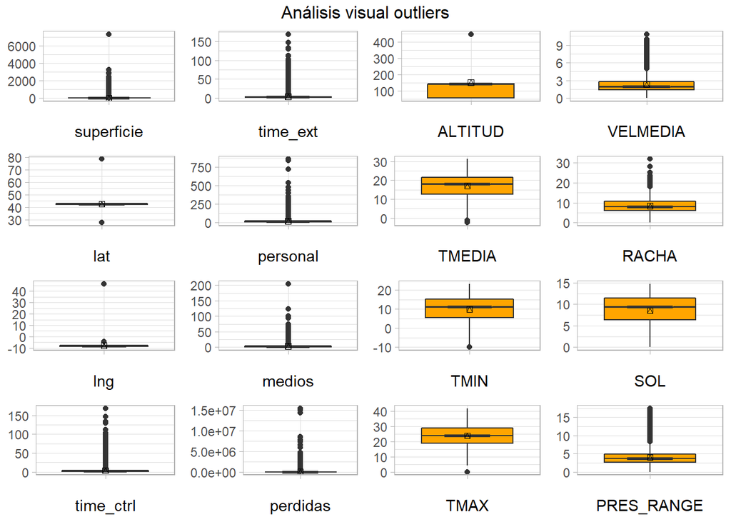

Análisis visual outliers

```r
listaGraf_input <- dfplot_box(numericas_input) #Boxplots
gridExtra::marrangeGrob(listaGraf_input, nrow = 4, ncol = 4, top='Análisis visual outliers')
```

En la mayoría de variables es evidente que hay valores extremos y a raíz del análisis gráfico, recibirán tratamientos distintos:

Para cada una de las variables contenidas en el subset de numéricas input, se van a identificar los valores extremos así como calcular su incidencia. Después se crea el dataframe de incidencia a partir de este, que contendrá en una columna los nombres de las variables y en otra su incidencia.

```r
outliers_superficie = FindOutliers(datos_galicia$superficie)
O_1 = InciOutliers(datos_galicia,outliers_superficie)

outliers_lat = FindOutliers(datos_galicia$lat)
O_2 = InciOutliers(datos_galicia,outliers_lat)

outliers_lng = FindOutliers(datos_galicia$lng)
O_3 = InciOutliers(datos_galicia,outliers_lng)

outliers_time_ctrl = FindOutliers(datos_galicia$time_ctrl)
O_4 = InciOutliers(datos_galicia,outliers_time_ctrl)

outliers_time_ext = FindOutliers(datos_galicia$time_ext)
O_5 = InciOutliers(datos_galicia,outliers_time_ext)

outliers_personal = FindOutliers(datos_galicia$personal)
O_6 = InciOutliers(datos_galicia,outliers_personal)

outliers_medios = FindOutliers(datos_galicia$medios)
O_7 = InciOutliers(datos_galicia,outliers_medios)

outliers_perdidas = FindOutliers(datos_galicia$perdidas)
O_8 = InciOutliers(datos_galicia,outliers_perdidas)

outliers_ALTITUD = FindOutliers(datos_galicia$ALTITUD)
O_9 = InciOutliers(datos_galicia,outliers_ALTITUD)

outliers_TMEDIA = FindOutliers(datos_galicia$TMEDIA)
O_10 = InciOutliers(datos_galicia,outliers_TMEDIA)

outliers_TMIN = FindOutliers(datos_galicia$TMIN)
O_11 = InciOutliers(datos_galicia,outliers_TMIN)

outliers_TMAX = FindOutliers(datos_galicia$TMAX)
O_12 = InciOutliers(datos_galicia,outliers_TMAX)

outliers_VELMEDIA = FindOutliers(datos_galicia$VELMEDIA)
O_13 = InciOutliers(datos_galicia,outliers_VELMEDIA)

outliers_RACHA = FindOutliers(datos_galicia$RACHA)
O_14 = InciOutliers(datos_galicia,outliers_RACHA)

outliers_SOL = FindOutliers(datos_galicia$SOL)
O_15 = InciOutliers(datos_galicia,outliers_SOL)

outliers_PRES_RANGE = FindOutliers(datos_galicia$PRES_RANGE)
O_16 = InciOutliers(datos_galicia,outliers_PRES_RANGE)


variable <- c(names(numericas_input))
incidencia <- c(O_1,O_2,O_3,O_4,O_5,O_6,O_7,O_8,O_9,O_10,O_11,O_12,O_13,O_14,O_15,O_16)

length(incidencia)
```

```
## [1] 16
```

En este dataset se realizará un tramiento parcial de los valores atípicos ya que algunos casos pueden llegar a ser considerados puntos de interés . Por ejemplo, en el caso de la superficie quemada,la presencia de valores anómalos es fuerte en esta variable, ya que un porcentaje significativo de las observaciones se corresponde con extensiones muy elevadas de terrenos quemado. La presencia de incendios con estas grandes dimensiones, aunque sea reducida en su conjunto es significativa, por eso no podemos omitirla en su totalidad.